# Comparing Risk and Return Across Equity ETFs, Gold, and Bitcoin (2016-2025)

## 1. Motivation

Every long-term investor faces two practical questions: how much diversification benefit do “alternative” assets like gold and Bitcoin actually provide alongside standard equity holdings, and have higher-risk assets historically been compensated with proportionally higher risk-adjusted returns? This project compares five investment assets over the past ten years (Jan 1, 2016 - Dec 31, 2025): VOO (S&P 500), QQQ (NASDAQ-100), IWM (Russell 2000), GLD (gold), and BTC-USD (Bitcoin).

## 2. Background: What These Assets Are

**NoteQuick primer for non-finance readers**

An **ETF (Exchange-Traded Fund)** is a basket of many stocks bundled into a single ticker that trades like one stock. Buying one share of VOO is a cheap, instant way to own a tiny slice of all 500 companies in the S&P 500.

| Ticker | What it is | What it represents |
| --- | --- | --- |
| **VOO** | Vanguard S&P 500 ETF | 500 largest U.S. companies — the standard “U.S. stock market” benchmark |
| **QQQ** | Invesco QQQ Trust | 100 largest non-financial NASDAQ stocks — heavy tech tilt (Apple, Microsoft, NVIDIA, etc.) |
| **IWM** | iShares Russell 2000 ETF | 2,000 small-cap U.S. companies — captures the size premium |
| **GLD** | SPDR Gold Trust | Tracks the price of physical gold — a classic “safe haven” / inflation hedge |
| **BTC-USD** | Bitcoin in U.S. dollars | The original cryptocurrency — high volatility, often pitched as “digital gold” |

The goal is to compare these very different asset types on a level playing field using ten years of daily price data.

## 3. Setup

```r
library(tidyverse)
library(tidyquant)
library(scales)
library(knitr)

tickers    <- c("VOO", "QQQ", "IWM", "GLD", "BTC-USD")
start_date <- as.Date("2016-01-01")
end_date   <- as.Date("2025-12-31")

theme_set(theme_minimal(base_size = 11))
```

## 4. Data Acquisition

The project uses two different types of data sources, as required by the rubric.

### 4.1 Source 1: Yahoo Finance API (via tidyquant)

**TipWhy “adjusted” closing price?**

The adjusted close corrects historical prices for dividends and stock splits, so a $1 invested on day one really does grow to the value shown by the chart. The raw close price would jump down on every dividend payment and make returns look smaller than they actually were.

```r
prices_raw <- tq_get(tickers,
                     get  = "stock.prices",
                     from = start_date,
                     to   = end_date)

prices <- prices_raw |>
  mutate(symbol = if_else(symbol == "BTC-USD", "BTC", symbol)) |>
  select(symbol, date, adjusted)

glimpse(prices)
```

```
Rows: 13,705
Columns: 3
$ symbol   <chr> "VOO", "VOO", "VOO", "VOO", "VOO", "VOO", "VOO", "VOO", "VOO"…
$ date     <date> 2016-01-04, 2016-01-05, 2016-01-06, 2016-01-07, 2016-01-08, …
$ adjusted <dbl> 155.0799, 155.3576, 153.3887, 149.6528, 148.0625, 148.0794, 1…
```

### 4.2 Source 2: FRED CSV downloads

**TipWhat is FRED and why use it?**

**FRED** (Federal Reserve Economic Data) is the St. Louis Fed’s free public database of U.S. economic time series. We pull two series:

- **CPI** (Consumer Price Index) — measures the price level of a basket of goods over time. The ratio of two CPI values tells us cumulative inflation between those dates.
- **3-month Treasury rate** — the interest rate on short-term U.S. government debt, used as the “risk-free rate” because Treasuries are considered the safest dollar-denominated investment.

CPI is used to compute inflation-adjusted (real) returns, and the 3-month Treasury rate is used as the risk-free rate in Sharpe ratio calculations. The helper below downloads each FRED series once into a local `data/` folder and reuses the cached copy on subsequent renders. The `data/` folder is committed to the repo so the project is self-contained, runs offline, and is fully reproducible by the grader.

```r
# Download a FRED series CSV once; reuse the local cached copy after that.
# Delete the file in data/ to force a refresh.
fred_csv <- function(series_id, dir = "data", na_strings = c("", "NA")) {
  dir.create(dir, showWarnings = FALSE, recursive = TRUE)
  path <- file.path(dir, paste0(series_id, ".csv"))
  if (!file.exists(path)) {
    url <- paste0("https://fred.stlouisfed.org/graph/fredgraph.csv?id=",
                  series_id)
    download.file(url, path, mode = "wb", quiet = TRUE)
  }
  read_csv(path, show_col_types = FALSE, na = na_strings)
}

cpi <- fred_csv("CPIAUCSL") |>
  rename(date = 1, cpi = 2) |>
  mutate(date = as.Date(date)) |>
  filter(date >= start_date, date <= end_date)

rf <- fred_csv("DGS3MO", na_strings = c(".", "", "NA")) |>
  rename(date = 1, rf_pct = 2) |>
  mutate(date   = as.Date(date),
         rf_pct = as.numeric(rf_pct)) |>
  filter(date >= start_date, date <= end_date) |>
  drop_na()

head(cpi)
```

```
# A tibble: 6 × 2
  date         cpi
  <date>     <dbl>
1 2016-01-01  238.
2 2016-02-01  237.
3 2016-03-01  238.
4 2016-04-01  239.
5 2016-05-01  240.
6 2016-06-01  240.
```

```r
head(rf)
```

```
# A tibble: 6 × 2
  date       rf_pct
  <date>      <dbl>
1 2016-01-04   0.22
2 2016-01-05   0.2
3 2016-01-06   0.21
4 2016-01-07   0.2
5 2016-01-08   0.2
6 2016-01-11   0.21
```

## 5. Data Transformation

**TipWhat is a “return”?**

A **return** is the percentage change in price from one day to the next. If a stock goes from $100 to $102, the daily return is `+2%`. We work with returns instead of raw prices because returns are comparable across assets (a $50 stock and a $5,000 stock can both have a 1% daily move) and tend to be roughly stationary, which is what most statistical methods assume.

This step satisfies the “at least one data transformation” requirement: prices are transformed to daily simple returns and pivoted from long to wide format so each asset becomes its own column for cross-asset analysis.

```r
# Daily simple returns (long format)
returns_long <- prices |>
  group_by(symbol) |>
  arrange(date) |>
  mutate(return = adjusted / lag(adjusted) - 1) |>
  filter(!is.na(return)) |>
  ungroup()

# Pivot to wide format; keep only days where ALL assets traded
# (excludes BTC weekend-only days for fair cross-asset comparison)
returns_wide <- returns_long |>
  select(symbol, date, return) |>
  pivot_wider(names_from = symbol, values_from = return) |>
  drop_na()

cat("Trading days in aligned panel:", nrow(returns_wide), "\n")
```

```
Trading days in aligned panel: 2512
```

```r
cat("Date range:",
    format(min(returns_wide$date)), "to",
    format(max(returns_wide$date)), "\n")
```

```
Date range: 2016-01-05 to 2025-12-30
```

## 6. Exploratory Analysis (Describing the Data)

### 6.1 Growth of $1 invested at the start of 2016

**NoteReading this chart**

This is the most intuitive way to compare assets: if you had put exactly $1 into each on Jan 1, 2016, what would it be worth on each later date? The y-axis uses a **log scale** so that a doubling looks the same size whether it’s $1 → $2 or $100 → $200, which keeps the high-flying assets from squashing the others into a flat line.

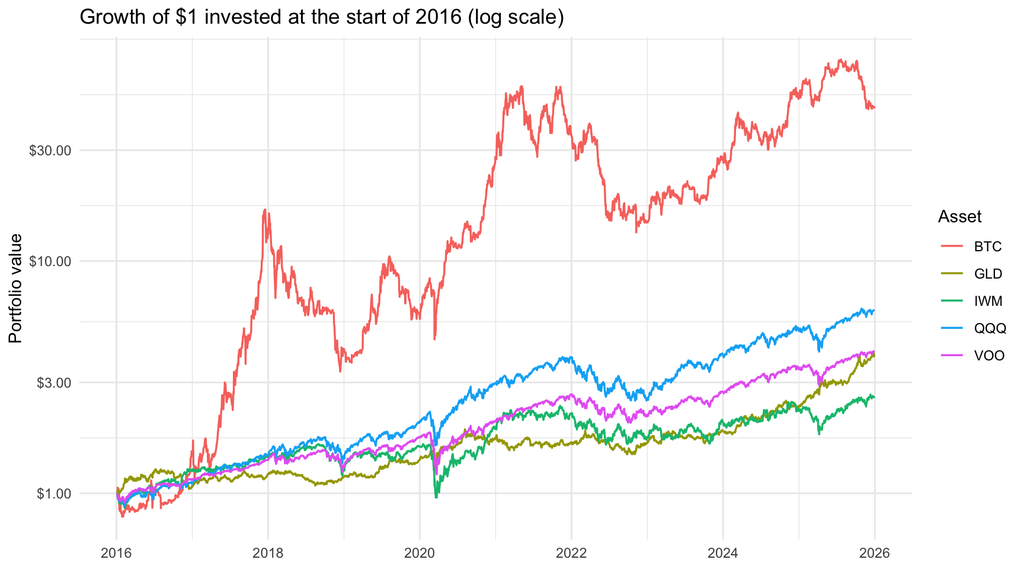

```r
growth <- returns_wide |>
  pivot_longer(-date, names_to = "symbol", values_to = "return") |>
  group_by(symbol) |>
  arrange(date) |>
  mutate(value = cumprod(1 + return)) |>
  ungroup()

ggplot(growth, aes(date, value, color = symbol)) +
  geom_line(linewidth = 0.6) +
  scale_y_log10(labels = dollar_format()) +
  labs(title = "Growth of $1 invested at the start of 2016 (log scale)",
       x = NULL, y = "Portfolio value", color = "Asset")
```

### 6.2 Daily return distributions

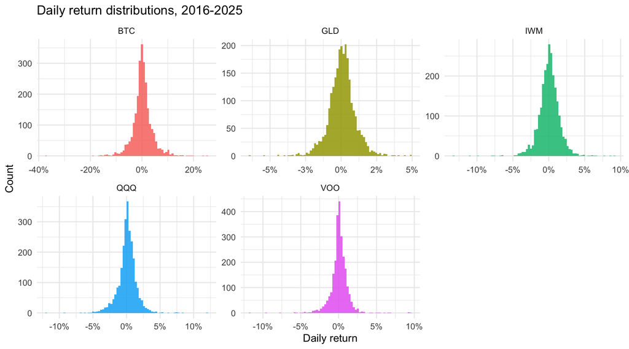

```r
returns_wide |>
  pivot_longer(-date, names_to = "symbol", values_to = "return") |>
  ggplot(aes(return, fill = symbol)) +
  geom_histogram(bins = 80, alpha = 0.85) +
  facet_wrap(~ symbol, scales = "free") +
  scale_x_continuous(labels = percent_format(accuracy = 1)) +
  labs(title = "Daily return distributions, 2016-2025",
       x = "Daily return", y = "Count") +
  theme(legend.position = "none")
```

BTC has visibly fatter tails than the equity ETFs (large gains and losses of more than ten percent in a single day), while GLD looks closest to a narrow, symmetric distribution.

## 7. Statistical Analysis (Supporting Conclusions)

### 7.1 Summary statistics by asset

**ImportantKey finance metrics in plain English**

- **Annualized return** — average daily return scaled up to a yearly figure (multiplied by 252 trading days per year). Answers “on average, how much did this asset gain per year?”
- **Annualized volatility** — standard deviation of daily returns scaled to a yearly figure (multiplied by √252). It’s the standard measure of risk: bigger number means bumpier ride.
- **Sharpe ratio** — `(return − risk-free rate) / volatility`. Reward per unit of risk. Higher is better. A Sharpe of 1.0 is considered good for a long-only investment; 2.0 is excellent.
- **Maximum drawdown** — the worst peak-to-trough loss an investor would have suffered if they bought at the worst time. A 50% drawdown means you’d have lost half your money at some point before recovering.

```r
# Helper: maximum drawdown from a vector of simple returns
max_drawdown <- function(r) {
  v <- cumprod(1 + r)
  abs(min((v - cummax(v)) / cummax(v)))
}

avg_rf <- mean(rf$rf_pct, na.rm = TRUE) / 100  # average annualized risk-free rate

summary_stats <- returns_wide |>
  pivot_longer(-date, names_to = "symbol", values_to = "return") |>
  group_by(symbol) |>
  summarize(
    obs               = n(),
    annualized_return = mean(return) * 252,
    annualized_vol    = sd(return)   * sqrt(252),
    sharpe            = (annualized_return - avg_rf) / annualized_vol,
    max_drawdown      = max_drawdown(return),
    .groups = "drop"
  ) |>
  arrange(desc(sharpe))

summary_stats |>
  mutate(across(annualized_return:max_drawdown, ~ round(.x, 3))) |>
  kable(caption = "Annualized return, volatility, Sharpe ratio, and max drawdown by asset (2016-2025)")
```

Annualized return, volatility, Sharpe ratio, and max drawdown by asset (2016-2025)

| symbol | obs | annualized_return | annualized_vol | sharpe | max_drawdown |
| --- | --- | --- | --- | --- | --- |
| BTC | 2512 | 0.571 | 0.607 | 0.903 | 0.799 |
| GLD | 2512 | 0.147 | 0.148 | 0.841 | 0.220 |
| QQQ | 2512 | 0.206 | 0.223 | 0.822 | 0.351 |
| VOO | 2512 | 0.157 | 0.181 | 0.744 | 0.340 |
| IWM | 2512 | 0.121 | 0.230 | 0.429 | 0.411 |

### 7.2 Correlation matrix (diversification check)

**NoteCorrelation and diversification**

**Correlation** measures how closely two assets move together, on a −1 to +1 scale: +1 means they move in lockstep, 0 means no relationship, −1 means they move in exact opposite directions. For a portfolio, you want assets with *low* correlation — that way when one zigs, another zags, and the total swings less than any single piece would on its own. This is the mathematical basis of **diversification**.

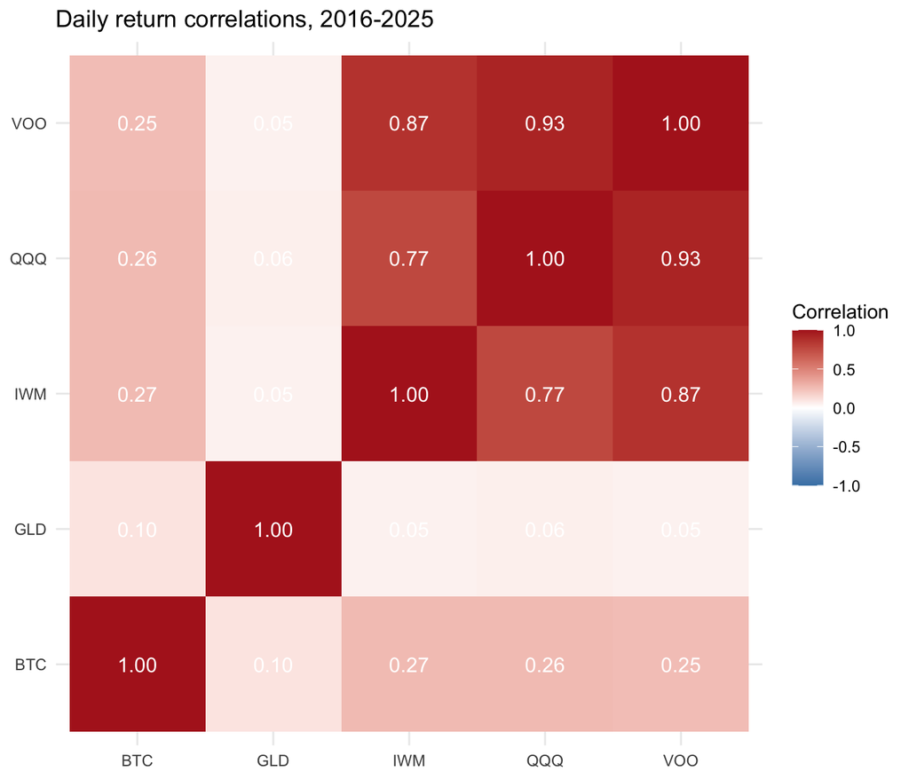

```r
cor_matrix <- returns_wide |>
  select(-date) |>
  cor()

cor_long <- as.data.frame(cor_matrix) |>
  rownames_to_column("asset1") |>
  pivot_longer(-asset1, names_to = "asset2", values_to = "correlation")

ggplot(cor_long, aes(asset1, asset2, fill = correlation)) +
  geom_tile() +
  geom_text(aes(label = sprintf("%.2f", correlation)),
            color = "white", size = 4) +
  scale_fill_gradient2(low = "steelblue", mid = "white", high = "firebrick",
                       midpoint = 0, limits = c(-1, 1)) +
  labs(title = "Daily return correlations, 2016-2025",
       x = NULL, y = NULL, fill = "Correlation")
```

The three equity ETFs (VOO, QQQ, IWM) are tightly correlated with each other (typically above 0.80), GLD is roughly uncorrelated with equities, and BTC shows a weak positive correlation with equities.

### 7.3 CAPM regression: beta vs the S&P 500

**ImportantWhat is CAPM, beta, and alpha?**

The **Capital Asset Pricing Model (CAPM)** is a workhorse finance model that explains an asset’s returns in terms of the overall stock market. We regress each asset’s excess return (return minus the risk-free rate) on the S&P 500’s excess return. The two key outputs:

- **Beta (β)** — how sensitive the asset is to market moves. β = 1 means it moves one-for-one with the S&P 500. β = 1.5 means it’s 50% more volatile (amplifies market moves). β near 0 means it’s roughly independent of the stock market.
- **Alpha (α)** — the average daily return that *isn’t* explained by market exposure. Positive alpha means the asset beat what its market sensitivity alone would predict.

**R²** tells us how much of the asset’s variation the S&P 500 actually explains — high R² means “this asset is essentially a leveraged bet on the stock market”; low R² means “this asset has its own life.”

This regresses each asset’s daily excess return on VOO’s daily excess return, producing a CAPM-style beta and alpha for each asset.

```r
returns_excess <- returns_wide |>
  left_join(rf |> select(date, rf_pct), by = "date") |>
  fill(rf_pct, .direction = "down") |>
  mutate(rf_daily = (rf_pct / 100) / 252) |>
  mutate(across(c(VOO, QQQ, IWM, GLD, BTC),
                ~ .x - rf_daily,
                .names = "ex_{.col}"))

assets_to_test <- c("QQQ", "IWM", "GLD", "BTC")

capm_results <- map_dfr(assets_to_test, function(asset) {
  fit <- lm(reformulate("ex_VOO", paste0("ex_", asset)),
            data = returns_excess)
  s <- summary(fit)
  tibble(
    asset         = asset,
    alpha_daily   = coef(fit)[1],
    beta          = coef(fit)[2],
    r_squared     = s$r.squared,
    p_value_alpha = s$coefficients[1, 4]
  )
})

capm_results |>
  mutate(across(where(is.numeric), ~ round(.x, 4))) |>
  kable(caption = "CAPM regression of each asset's daily excess return on VOO")
```

CAPM regression of each asset’s daily excess return on VOO

| asset | alpha_daily | beta | r_squared | p_value_alpha |
| --- | --- | --- | --- | --- |
| QQQ | 0.0001 | 1.1515 | 0.8679 | 0.2637 |
| IWM | -0.0002 | 1.1030 | 0.7491 | 0.1754 |
| GLD | 0.0005 | 0.0418 | 0.0026 | 0.0113 |
| BTC | 0.0017 | 0.8501 | 0.0640 | 0.0199 |

Equity ETFs (QQQ, IWM) all have betas close to or above 1, as expected. GLD’s beta is near zero (gold barely moves with the stock market on a daily basis), and BTC has a modest positive beta with very low R-squared, meaning most of its variation is unexplained by stock-market moves.

## 8. Feature Beyond Class: Rolling 12-Month Correlations

**NoteWhy “rolling” correlation matters**

A single correlation number for the whole 10-year window hides whether the relationship was stable or changed over time. A **rolling correlation** computes the correlation over a moving window (here, the most recent 252 trading days ≈ 1 year), then slides it forward day by day. The result shows how diversification benefits have evolved through different market regimes — useful because a hedge that worked in 2017 might not work in 2022.

This section uses a rolling 252-trading-day window to track how the correlation between Bitcoin and equities (and gold and equities) has shifted over the period — something a static correlation matrix cannot reveal.

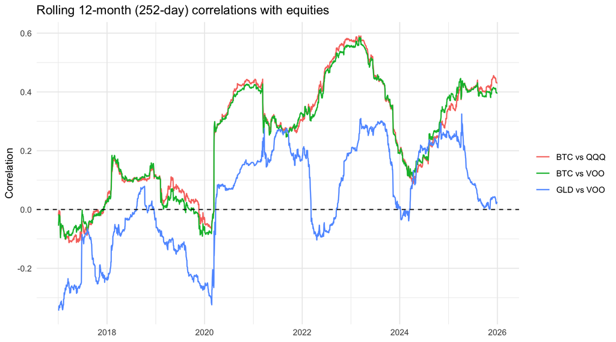

```r
# Manual rolling correlation (no extra packages needed)
rolling_cor <- function(x, y, n = 252) {
  out <- rep(NA_real_, length(x))
  for (i in n:length(x)) {
    out[i] <- cor(x[(i - n + 1):i], y[(i - n + 1):i])
  }
  out
}

rolling_corr <- returns_wide |>
  arrange(date) |>
  mutate(
    `BTC vs VOO` = rolling_cor(BTC, VOO),
    `BTC vs QQQ` = rolling_cor(BTC, QQQ),
    `GLD vs VOO` = rolling_cor(GLD, VOO)
  ) |>
  select(date, `BTC vs VOO`, `BTC vs QQQ`, `GLD vs VOO`) |>
  drop_na() |>
  pivot_longer(-date, names_to = "pair", values_to = "correlation")

ggplot(rolling_corr, aes(date, correlation, color = pair)) +
  geom_line(linewidth = 0.6) +
  geom_hline(yintercept = 0, linetype = "dashed") +
  labs(title = "Rolling 12-month (252-day) correlations with equities",
       x = NULL, y = "Correlation", color = NULL)
```

## 9. Inflation-Adjusted (Real) Returns

**NoteNominal vs real returns**

A **nominal** return is the headline number — the actual change in dollar value. A **real** return strips out inflation to show the change in *purchasing power*. If your portfolio grew 30% but prices also rose 30%, your real return was zero — you can buy exactly the same amount of stuff as before. This is why long-horizon investors care more about real returns than nominal ones.

A quick sanity check using the second source (FRED CPI): converting nominal cumulative returns to real returns.

```r
# Pull start and end CPI to compute total inflation over the period
cpi_start <- cpi |> arrange(date) |> slice(1)  |> pull(cpi)
cpi_end   <- cpi |> arrange(date) |> slice(n()) |> pull(cpi)
total_inflation <- cpi_end / cpi_start - 1

cat(sprintf("Total CPI inflation, %s to %s: %.1f%%\n",
            format(min(cpi$date)), format(max(cpi$date)),
            100 * total_inflation))
```

```
Total CPI inflation, 2016-01-01 to 2025-12-01: 37.2%
```

```r
nominal_growth <- growth |>
  group_by(symbol) |>
  summarize(nominal_final = last(value), .groups = "drop")

real_returns <- nominal_growth |>
  mutate(real_final           = nominal_final / (1 + total_inflation),
         nominal_total_return = nominal_final - 1,
         real_total_return    = real_final    - 1) |>
  arrange(desc(real_total_return))

real_returns |>
  mutate(across(where(is.numeric), ~ round(.x, 3))) |>
  kable(caption = "Nominal vs real (inflation-adjusted) total return, 2016-2025")
```

Nominal vs real (inflation-adjusted) total return, 2016-2025

| symbol | nominal_final | real_final | nominal_total_return | real_total_return |
| --- | --- | --- | --- | --- |
| BTC | 46.364 | 33.796 | 45.364 | 32.796 |
| QQQ | 6.082 | 4.433 | 5.082 | 3.433 |
| VOO | 4.061 | 2.960 | 3.061 | 1.960 |
| GLD | 3.877 | 2.826 | 2.877 | 1.826 |
| IWM | 2.567 | 1.871 | 1.567 | 0.871 |